# PracticalMachineLearningAssignment

Hadi Tjioe

## Background

Using devices such as Jawbone Up, Nike FuelBand, and Fitbit it is now possible to collect a large amount of data about personal activity relatively inexpensively. These type of devices are part of the quantified self movement - a group of enthusiasts who take measurements about themselves regularly to improve their health, to find patterns in their behavior, or because they are tech geeks. One thing that people regularly do is quantify how much of a particular activity they do, but they rarely quantify how well they do it. In this project, your goal will be to use data from accelerometers on the belt, forearm, arm, and dumbell of 6 participants. They were asked to perform barbell lifts correctly and incorrectly in 5 different ways. More information is available from the website here: http://groupware.les.inf.puc-rio.br/har (see the section on the Weight Lifting Exercise Dataset).

## Goal

The goal of your project is to predict the manner in which they did the exercise. This is the “classe” variable in the training set. You may use any of the other variables to predict with. You should create a report describing how you built your model, how you used cross validation, what you think the expected out of sample error is, and why you made the choices you did. You will also use your prediction model to predict 20 different test cases.

## 1. Preparation

Prepraration includes calling the libraries, setting up seed to ensure repeatability, and setting up working directory.

```r
library(knitr)
library(caret)
library(rpart)
library(randomForest)
library(corrplot)
set.seed(333)
setwd("D:/Coursera/PracticalMachineLearning/")
```

## 2. Loading Data

Loading data and grouping the train set to train (70%) and validation (30%). Test set is unchanged.

The training data for this project was pre-downloaded from: https://d396qusza40orc.cloudfront.net/predmachlearn/pml-training.csv

The test data was pre-downloaded from: https://d396qusza40orc.cloudfront.net/predmachlearn/pml-testing.csv

```r
training <- read.csv("pml-training.csv")
testing <- read.csv("pml-testing.csv")

inTrain  <- createDataPartition(training$classe, p=0.7, list=FALSE)
TrainSet <- training[inTrain, ]
ValidationSet  <- training[-inTrain, ]
TestSet <- testing

dim(TrainSet)
```

```
## [1] 13737   160
```

```r
dim(ValidationSet)
```

```
## [1] 5885  160
```

Data sets are observed to have many columns with NA and static values which will not be valuable for modelling purpose.

```r
# removing mostly NA columns
checkNA <- sapply(TrainSet, function(x) mean(is.na(x))) > 0.9
TrainSet <- TrainSet[, checkNA==FALSE]
ValidationSet  <- ValidationSet[, checkNA==FALSE]

# removing static columns
nearZeroVariance <- nearZeroVar(TrainSet)
TrainSet <- TrainSet[, -nearZeroVariance]
ValidationSet  <- ValidationSet[, -nearZeroVariance]

# removing 1st 5 columns
TrainSet <- TrainSet[, -(1:5)]
ValidationSet  <- ValidationSet[, -(1:5)]

dim(TrainSet)
```

```
## [1] 13737    54
```

```r
dim(ValidationSet)
```

```
## [1] 5885   54
```

After pre-processing, only 54 columns remained in TrainSet and 54 columns remained in ValidationSet.

## 3. Colinearity Check

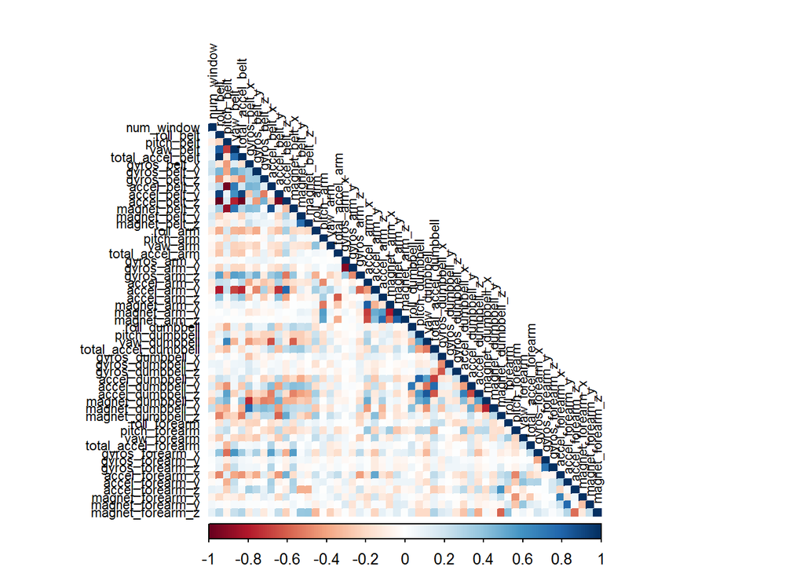

```r
corMatrix <- cor(TrainSet[, -54])
corrplot(corMatrix, method = "color", type = "lower", tl.cex = 0.7, tl.col = rgb(0, 0, 0))
```

The above plot show the degree of correlation of each of the variables in colors (darker colors mean higher correlation). In this case, most of the variables are observed to have no correlations between them. Few of them have high correlation between them which we can use PCA to combine them first. However, since the number of highly correlated variables are limited, PCA is not applied in this case.

## 4. Modelling

# a. Random Forest

```r
modelRF <- train(classe ~ ., method="rf", data=TrainSet, trControl=trainControl(method="cv",number=3))
modelRF$finalModel
```

```
##
## Call:
##  randomForest(x = x, y = y, mtry = param$mtry)
##                Type of random forest: classification
##                      Number of trees: 500
## No. of variables tried at each split: 27
##
##         OOB estimate of  error rate: 0.17%
## Confusion matrix:
##      A    B    C    D    E class.error
## A 3906    0    0    0    0 0.000000000
## B    6 2650    2    0    0 0.003009782
## C    0    5 2389    2    0 0.002921536
## D    0    0    4 2247    1 0.002220249
## E    0    1    0    3 2521 0.001584158
```

Prediction on ValidationSet

```r
predictRF <- predict(modelRF, newdata=ValidationSet)
confRF <- confusionMatrix(predictRF, ValidationSet$classe)
confRF
```

```
## Confusion Matrix and Statistics
##
##           Reference
## Prediction    A    B    C    D    E
##          A 1673    2    0    0    0
##          B    0 1135    1    0    0
##          C    0    1 1025    4    0
##          D    0    1    0  960    2
##          E    1    0    0    0 1080
##
## Overall Statistics
##
##                Accuracy : 0.998
##                  95% CI : (0.9964, 0.9989)
##     No Information Rate : 0.2845
##     P-Value [Acc > NIR] : < 2.2e-16
##
##                   Kappa : 0.9974
##  Mcnemar's Test P-Value : NA
##
## Statistics by Class:
##
##                      Class: A Class: B Class: C Class: D Class: E
## Sensitivity            0.9994   0.9965   0.9990   0.9959   0.9982
## Specificity            0.9995   0.9998   0.9990   0.9994   0.9998
## Pos Pred Value         0.9988   0.9991   0.9951   0.9969   0.9991
## Neg Pred Value         0.9998   0.9992   0.9998   0.9992   0.9996
## Prevalence             0.2845   0.1935   0.1743   0.1638   0.1839
## Detection Rate         0.2843   0.1929   0.1742   0.1631   0.1835
## Detection Prevalence   0.2846   0.1930   0.1750   0.1636   0.1837
## Balanced Accuracy      0.9995   0.9981   0.9990   0.9976   0.9990
```

# b. Decision Tree

```r
modelDT <- train(classe ~ ., method="rpart", data=TrainSet)
modelDT$finalModel
```

```
## n= 13737
##
## node), split, n, loss, yval, (yprob)
##       * denotes terminal node
##
##  1) root 13737 9831 A (0.28 0.19 0.17 0.16 0.18)
##    2) roll_belt< 130.5 12577 8681 A (0.31 0.21 0.19 0.18 0.11)
##      4) pitch_forearm< -34.35 1126    3 A (1 0.0027 0 0 0) *
##      5) pitch_forearm>=-34.35 11451 8678 A (0.24 0.23 0.21 0.2 0.12)
##       10) magnet_dumbbell_y< 437.5 9655 6948 A (0.28 0.18 0.24 0.19 0.11)
##         20) roll_forearm< 123.5 5969 3551 A (0.41 0.18 0.18 0.17 0.062) *
##         21) roll_forearm>=123.5 3686 2452 C (0.078 0.17 0.33 0.23 0.18) *
##       11) magnet_dumbbell_y>=437.5 1796  873 B (0.037 0.51 0.04 0.22 0.19) *
##    3) roll_belt>=130.5 1160   10 E (0.0086 0 0 0 0.99) *
```

Prediction on ValidationSet

```r
predictDT <- predict(modelDT, newdata=ValidationSet)
confDT <- confusionMatrix(predictDT, ValidationSet$classe)
confDT
```

```
## Confusion Matrix and Statistics
##
##           Reference
## Prediction    A    B    C    D    E
##          A 1530  479  495  438  153
##          B   24  373   38  181  154
##          C  116  287  493  345  294
##          D    0    0    0    0    0
##          E    4    0    0    0  481
##
## Overall Statistics
##
##                Accuracy : 0.4889
##                  95% CI : (0.476, 0.5017)
##     No Information Rate : 0.2845
##     P-Value [Acc > NIR] : < 2.2e-16
##
##                   Kappa : 0.3314
##  Mcnemar's Test P-Value : NA
##
## Statistics by Class:
##
##                      Class: A Class: B Class: C Class: D Class: E
## Sensitivity            0.9140  0.32748  0.48051   0.0000  0.44455
## Specificity            0.6284  0.91635  0.78555   1.0000  0.99917
## Pos Pred Value         0.4943  0.48442  0.32117      NaN  0.99175
## Neg Pred Value         0.9484  0.85024  0.87747   0.8362  0.88870
## Prevalence             0.2845  0.19354  0.17434   0.1638  0.18386
## Detection Rate         0.2600  0.06338  0.08377   0.0000  0.08173
## Detection Prevalence   0.5259  0.13084  0.26083   0.0000  0.08241
## Balanced Accuracy      0.7712  0.62192  0.63303   0.5000  0.72186
```

Accuracy of the above 2 models are summarized as follow:

1. Random Forest - 0.9979609
2. Decision Tree - 0.48887

## 5. Prediction

As Random Forest has the highest accuracy, it will be used to predict the TestSet result.

```r
predictRF <- predict(modelRF, newdata=TestSet)
predictRF
```

```
##  [1] B A B A A E D B A A B C B A E E A B B B
## Levels: A B C D E
```